# Mystic mops project 3

Anna Tedikova, Alina Prokhorenko, Polina Dymova

15 Май 2022

## Team members & contributions

*Anna Tedikova* - plots & descriptives of variables; regression models; comparing model fits; assessing the chosen model; interpreting the coefficients; output table & conclusion.

*Alina Prokhorenko* - correlations, scatterplots, boxplot; assessing the chosen model; interpreting the coefficients; output table & conclusion.

*Polina Dymova* - background & hypotheses; assessing the chosen model; interpreting the coefficients; regression equation; output table & conclusion.

## Topic

Internet use based on respondents’ characteristics (age, education, happiness).

## Country

Finland

# Variables choice & hypotheses

## Background & hypotheses

Outcome variable - **Internet use on a typical day in minutes**

1. Our first research hypothesis is based on the relationship between **Internet use and age** - we assume that children and the elderly will use the Internet less than young and middle-aged people. In this hypothesis we expect a **negative correlation** with outliers starting around age 50, hence the correlation in this case will be of **medium strength**. This hypothesis is based on the report we found [1], where authors state that older adults do not use the Internet very frequently - “Internet usage is much less prevalent among members of the “G.I. Generation” (adults who are currently 76 and older) than among other age groups.”
2. The second research hypothesis is about the dependence of the **Internet use on an education a person has**. We assume that more educated people are from higher classes with greater access to the Internet, moreover, they are more advanced Internet users. Here we can also mention that the Internet is used for education, so the longer you study, the more you use it. Therefore, here we expect to observe a **positive correlation of small to moderate strength**. In one of the researches [2] we found that “…the percentages of people with internet access grew primarily in the middle and older age groups between 2002 and 2014. Furthermore, being male and having a higher education were both associated with greater odds of internet access. <…> Finally, both greater income and cognitive ability were associated with greater odds of internet access, while providing care for a grandchild was significantly associated with internet access only among the oldest age group.”
3. Our third hypothesis is about the dependence of **Internet use on happiness**. We assume that unhappy people can use internet resources for escapism (i.e. to cope with unhappiness) or to help themselves, and happy people do not use it that much because they do not need to escape from unpleasant reality. Here we expect a **small to medium strength negative correlation**. This hypothesis is based on the information we gathered - a work [3] where authors state that “The present data imply that heavier computer users are not so much disinhibited or stimulus seeking, but have a poorer self-esteem. Whether the poorer self-esteem leads to greater computer use, or prolonged time on the Internet leads to problems that affect self-worth is not clear.”. As there is no self-esteem variable in ESS dataset we have chosen happiness level as those two seem similar.
4. Our fourth hypothesis includes a categorical variable, but it is similar to the one in the 2nd hypothesis - **education level of the respondent**. As those variables virtually correspond to the same concept, we expect to see similar correlation as in the second hypothesis.

## Exploring the variables

Let’s first check the types of variables and how they are stored in R.

```r
glimpse(ESS3)
```

```
## Rows: 1,755
## Columns: 5
## $ netustm <dbl+lbl> 120, 240,  60, 240, 570, 240, 150, 300,  NA,  NA, 120,  60~
## $ agea    <dbl+lbl> 71, 29, 77, 46, 57, 39, 19, 43, 90, 65, 36, 45, 73, 55, 24~
## $ eduyrs  <dbl+lbl> 10, 18,  8, 21, 11, 17, 12, 15, 13,  8, 17, 17, 14, 14, 12~
## $ happy   <dbl+lbl>  9,  9,  9,  9,  9, 10,  8,  8,  6,  8, 10,  9,  8,  9,  8~
## $ eisced  <dbl+lbl> 5, 7, 1, 7, 4, 6, 2, 4, 4, 1, 6, 7, 5, 4, 4, 2, 6, 5, 4, 6~
```

```r
class(ESS3$netustm)
```

```
## [1] "haven_labelled" "vctrs_vctr"     "double"
```

```r
class(ESS3$agea)
```

```
## [1] "haven_labelled" "vctrs_vctr"     "double"
```

```r
class(ESS3$eduyrs)
```

```
## [1] "haven_labelled" "vctrs_vctr"     "double"
```

```r
class(ESS3$happy)
```

```
## [1] "haven_labelled" "vctrs_vctr"     "double"
```

```r
class(ESS3$eisced)
```

```
## [1] "haven_labelled" "vctrs_vctr"     "double"
```

We can see that all variables are stored as vectors. For easier analysis let’s convert the internet use `netustm`, age `agea`, education years `eduyrs` and happiness level `happy` into numeric variables; recode education level `eisced` into more convenient categories; and rename the new variables.

```r
ESS3$netusemin <- as.numeric(ESS3$netustm)
ESS3$age <- as.numeric(ESS3$agea)
ESS3$eduyrs_n <- as.numeric(ESS3$eduyrs)
ESS3$happylvl <- as.numeric(as.character(ESS3$happy))

class(ESS3$netusemin)
```

```
## [1] "numeric"
```

```r
class(ESS3$age)
```

```
## [1] "numeric"
```

```r
class(ESS3$eduyrs_n)
```

```
## [1] "numeric"
```

```r
class(ESS3$happylvl)
```

```
## [1] "numeric"
```

```r
ESS3$edlvl <- as.numeric(as.character(ESS3$eisced))
ESS3$edlvl[ESS3$edlvl == "0" | ESS3$edlvl == "1" |
                 ESS3$edlvl == "2"] <- "lower secondary or less"
ESS3$edlvl[ESS3$edlvl == "3" | ESS3$edlvl == "4"] <- "upper secondary"
ESS3$edlvl[ESS3$edlvl == "5"] <- "advanced vocational"
ESS3$edlvl[ESS3$edlvl == "6"] <- "BA"
ESS3$edlvl[ESS3$edlvl == "7"] <- "MA or higher"

ESS3$edlvl <- factor(ESS3$edlvl, ordered = TRUE,
                               levels = c("lower secondary or less",
                                          "upper secondary",
                                          "advanced vocational",
                                          "BA", "MA or higher"))
class(ESS3$edlvl)
```

```
## [1] "ordered" "factor"
```

# Plots & descriptives for variables

Now that we have recoded and renamed each variable (again, for convenience), we can build plots to see how they are distributed.

## Numeric variables

Let’s start with histograms for numeric variables. We need to assess their normality before performing correlation tests, as based on that (and other assumptions) we will choose the appropriate method.

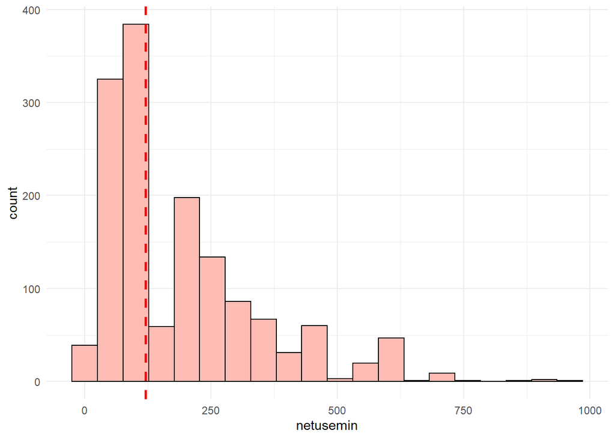

```r
ggplot(ESS3, aes(x=netusemin)) +
  geom_histogram(bins=20, color="black", fill="#fdbcb4")+
  geom_vline(aes(xintercept=median(netustm)), color="red", linetype="dashed", size=1)+
  theme_minimal()
```

- `netusemin` - internet usage per day in minutes, outcome variable, ratio:
- here we see that the variable is severely right-skewed, so most people tend to spend less than 400-500 min a day on the internet; the distribution is unimodal and somewhat bell-shaped; it is far from normal.

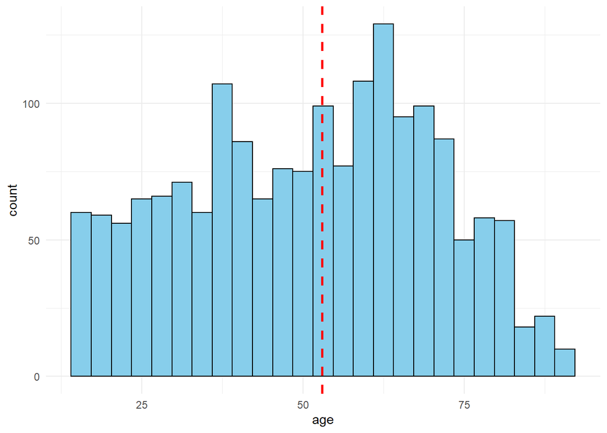

```r
ggplot(ESS3, aes(x=age)) +
  geom_histogram(bins=25,color="black", fill="#87CEEB")+
  geom_vline(aes(xintercept=median(agea)), color="red", linetype="dashed", size=1)+
  theme_minimal()
```

- `age` - calculated age of respondents, full years, ratio:
- this variable is also unimodal, but we cannot say that it is bell-shaped or normal; the researchers seemed to collect respondents of different age groups, so there is a similar amount of most ages.

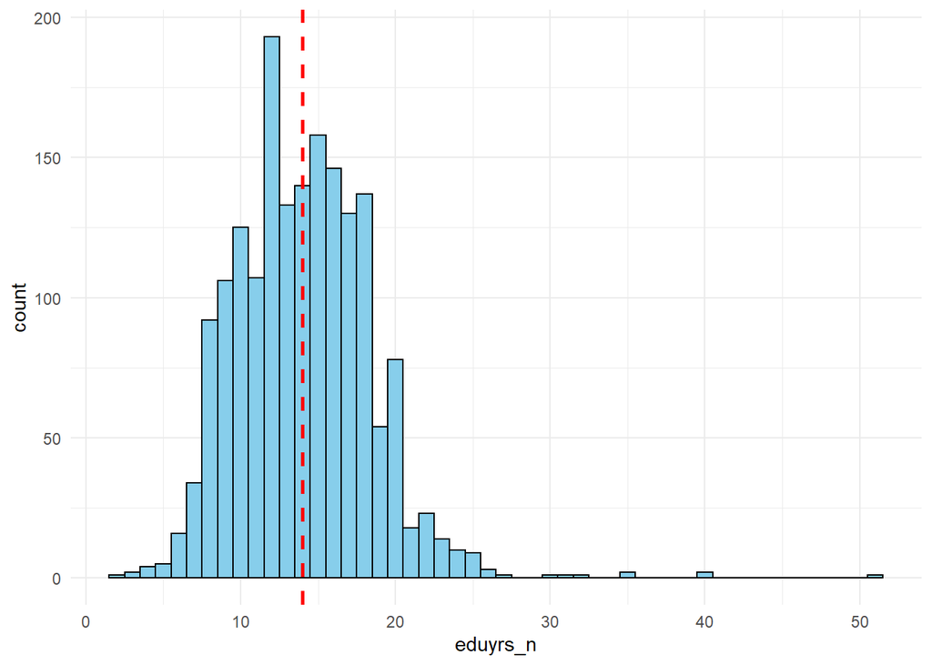

```r
ggplot(ESS3, aes(x=eduyrs_n)) +
  geom_histogram(bins = 50,color="black", fill="#87CEEB")+
  geom_vline(aes(xintercept=median(eduyrs)), color="red", linetype="dashed", size=1)+
  theme_minimal()
```

- `eduyrs_n` - sum of years spent on education, full years, ratio:
- this distribution is unimodal and bell-shaped, but is right-skewed because of several outliers (people who spent over 30 years on education); again, it is not normal.

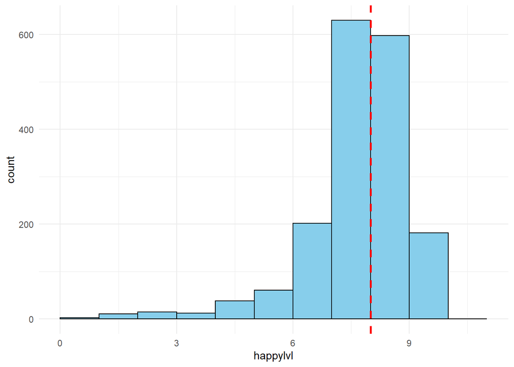

```r
ggplot(ESS3, aes(x=happylvl)) +
  geom_histogram(breaks = seq(0, 11, by=1),color="black", fill="#87CEEB")+
  geom_vline(aes(xintercept=median(happy)), color="red", linetype="dashed", size=1)+
  theme_minimal()
```

- `happylvl` - self-assessed level of happiness of respondents, quasi-interval:
- this variable’s distribution is left-skewed, unimodal and close to bell-shaped; most respondents seem to indicate quite high levels of happiness (7 and higher).

## Categorical variables

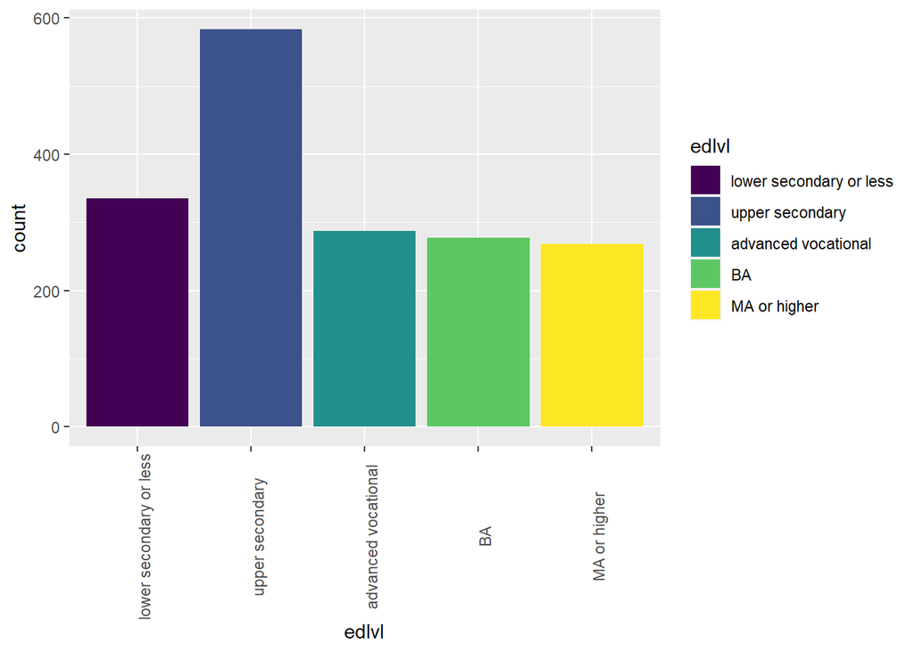

```r
ESS3_2=ESS3%>%
filter(! is.na(edlvl))
ggplot(ESS3_2, aes(x=edlvl, fill=edlvl)) +
  geom_bar()+
  theme(axis.text.x = element_text(angle = 90))
```

## Descriptives of variables

Now we create a data frame only with our new variables and label them. Then we create a table with value descriptives.

```r
ESS3_1 <- c("netusemin", "age", "eduyrs_n", "happylvl", "edlvl")
ESS3_1 <- ESS3[ESS3_1]
ESS3_1
```

```
## # A tibble: 1,755 x 5
##    netusemin   age eduyrs_n happylvl edlvl
##        <dbl> <dbl>    <dbl>    <dbl> <ord>
##  1       120    71       10        9 advanced vocational
##  2       240    29       18        9 MA or higher
##  3        60    77        8        9 lower secondary or less
##  4       240    46       21        9 MA or higher
##  5       570    57       11        9 upper secondary
##  6       240    39       17       10 BA
##  7       150    19       12        8 lower secondary or less
##  8       300    43       15        8 upper secondary
##  9        NA    90       13        6 upper secondary
## 10        NA    65        8        8 lower secondary or less
## # ... with 1,745 more rows
```

```r
labs <- c("Internet use on a typical day, in minutes",
          "Age of respondent, calculated",
          "Years of full-time education completed",
          "Happiness level, scale 0-10",
          "Education level")

ESS3_1 <- set_label(ESS3_1, label = labs)
view_df(ESS3_1[1:5], show.prc = F, verbose = F)
```

Data frame: ESS3_1[1:5]

| ID | Name | Label | Values | Value Labels |
| --- | --- | --- | --- | --- |
| 1 | netusemin | Internet use on a typical day, in minutes | *range: 0-960* |  |
| 2 | age | Age of respondent, calculated | *range: 15-90* |  |
| 3 | eduyrs_n | Years of full-time education completed | *range: 2-51* |  |
| 4 | happylvl | Happiness level, scale 0-10 | *range: 0-10* |  |
| 5 | edlvl | Education level |  | lower secondary or less upper secondary advanced vocational BA MA or higher |

We can see that for education level there are categories listed. Happiness level’s range corresponds to the scale that was used in the survey. Internet use is 0-960, so we identified its type (ratio) correctly. Years of education and age do not start from 0, however, we think it is still suitable to call them ratio variables as technically there is an absolute 0 for them.

```r
ESS3_1 %>%
  describe() %>%
  knitr::kable(digits = 2)
```

|  | vars | n | mean | sd | median | trimmed | mad | min | max | range | skew | kurtosis | se |
| --- | --- | --- | --- | --- | --- | --- | --- | --- | --- | --- | --- | --- | --- |
| netusemin | 1 | 1468 | 192.22 | 156.02 | 120 | 167.09 | 88.96 | 0 | 960 | 960 | 1.44 | 1.88 | 4.07 |
| age | 2 | 1755 | 50.90 | 19.14 | 53 | 51.11 | 22.24 | 15 | 90 | 75 | -0.10 | -1.00 | 0.46 |
| eduyrs_n | 3 | 1747 | 14.05 | 4.32 | 14 | 13.88 | 4.45 | 2 | 51 | 49 | 0.93 | 4.61 | 0.10 |
| happylvl | 4 | 1752 | 8.18 | 1.35 | 8 | 8.32 | 1.48 | 0 | 10 | 10 | -1.80 | 5.55 | 0.03 |
| edlvl* | 5 | 1750 | 2.75 | 1.34 | 2 | 2.69 | 1.48 | 1 | 5 | 4 | 0.37 | -1.10 | 0.03 |

We are interested in the last 5 rows, except edlvl. As we can see, Internet use in minutes `netusemin` is highly right-skewed, while Number of years spent in education `eduyrs_n` is moderately right-skewed. Happiness level `happylvl` is highly left-skewed. Age, `age` on the other hand, is pretty close to being symmetrically distributed.

# Correlation

Before performing correlation test, we need to decide which method to use - parametric Pearson’s test or non-parametric Spearman’s or Kendall’s. For that, we need to check several assumptions of Pearson’s correlation test:

- *linearity*
- *outliers*
- *homoscedasticity*
- *normality*

## Linearity + Outliers + Homoscedasticity

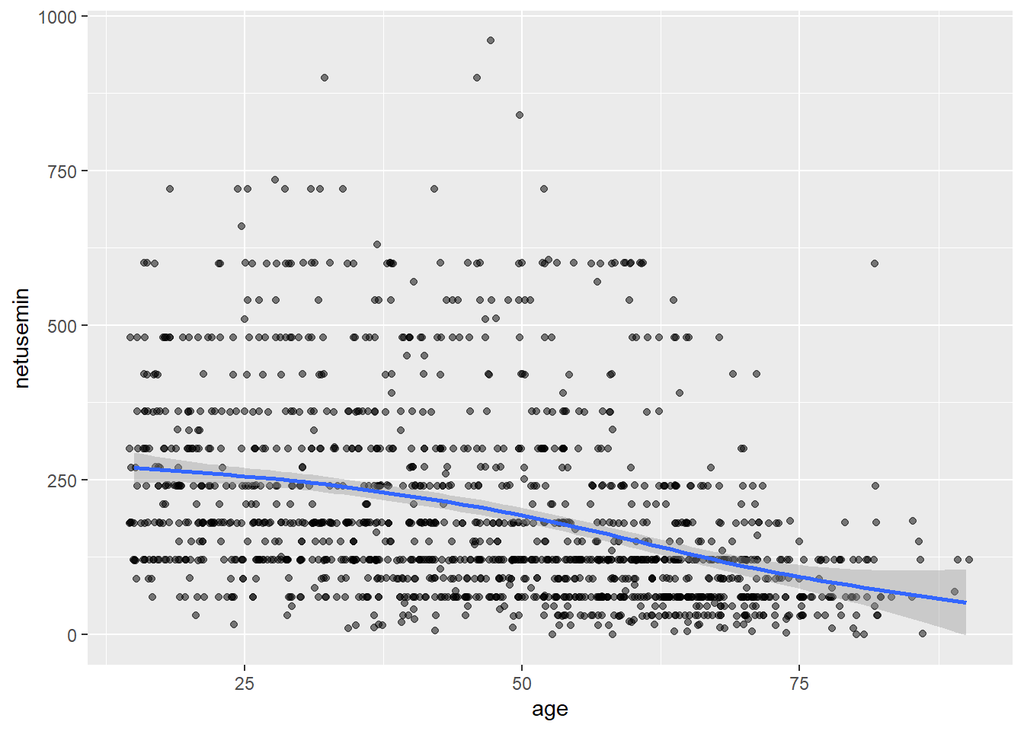

```r
ggplot(ESS3, aes(x = age, y = netusemin)) +
  geom_point(alpha=0.5, position = "jitter") +
  geom_smooth()
```

As we can see, the relationship `netusemin ~ age` is hardly linear. Even though we see that the line shows some kind of pattern, if we look at the data points themselves, it is far from obvious and there are a lot of outliers. Thus, it is **non-linear relationships with significant outliers**. **Severe heteroscedasticity** is also visible.

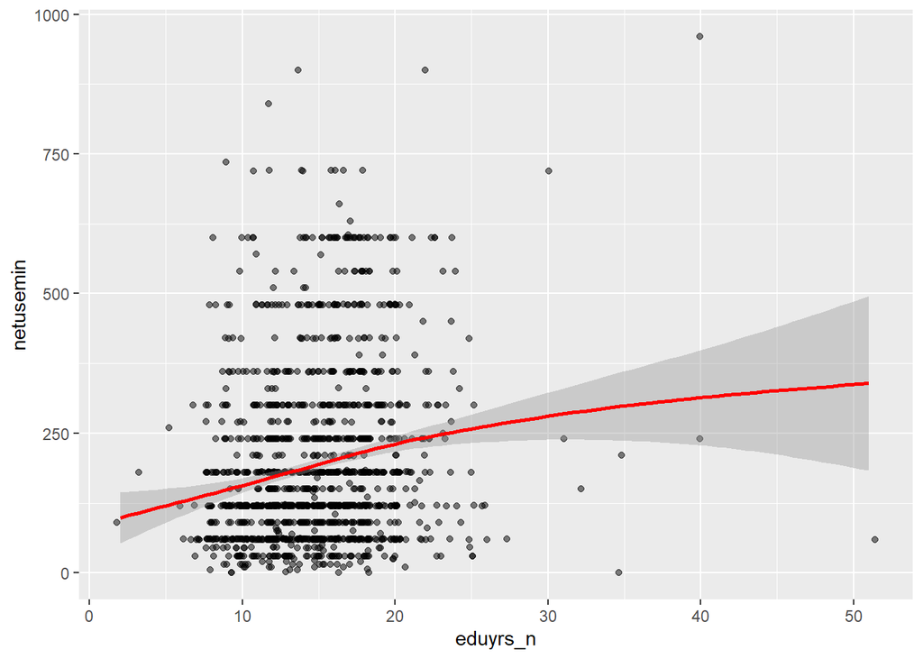

```r
ggplot(ESS3, aes(x = eduyrs_n, y= netusemin)) +
  geom_point(alpha=0.5, position = "jitter")+
  geom_smooth(color = "red")
```

Even though the outliers are not so visible, `netusemin ~ eduyrs_n` relationship is **non-linear**, since the data points are clustered together. It is **hard to estimate homoscedasticity** here, since there is no visible line.

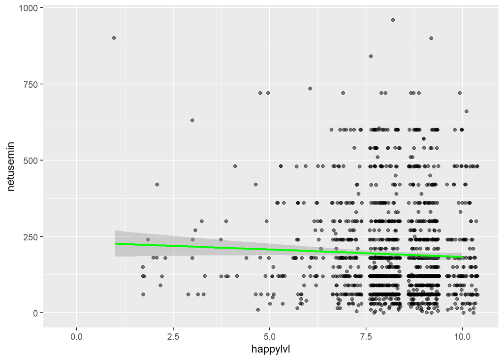

```r
ggplot(ESS3, aes(x = happylvl, y= netusemin)) +
  geom_point(alpha=0.5, position = "jitter")+
  geom_smooth(color = "green")
```

`netusemin ~ happylvl` relationship is **hardly linear** too. The data points are clustered together, even though there are some noticable outliers. Again, it is **hard to estimate homoscedasticity** here, since there is no visible line.

### Linearity + Outliers conclusion

The relationships between chosen variables are either close to non-linear or non-linear, the outliers are significantly noticable in 2 of the graphs. The homoscedasticity is either hard to estimate or not present. Thus, our variables do not pass the linearity, outliers and homoscedasticity assumptions.

## Normality assumption

Let’s check the normality of each variables’ distributions:

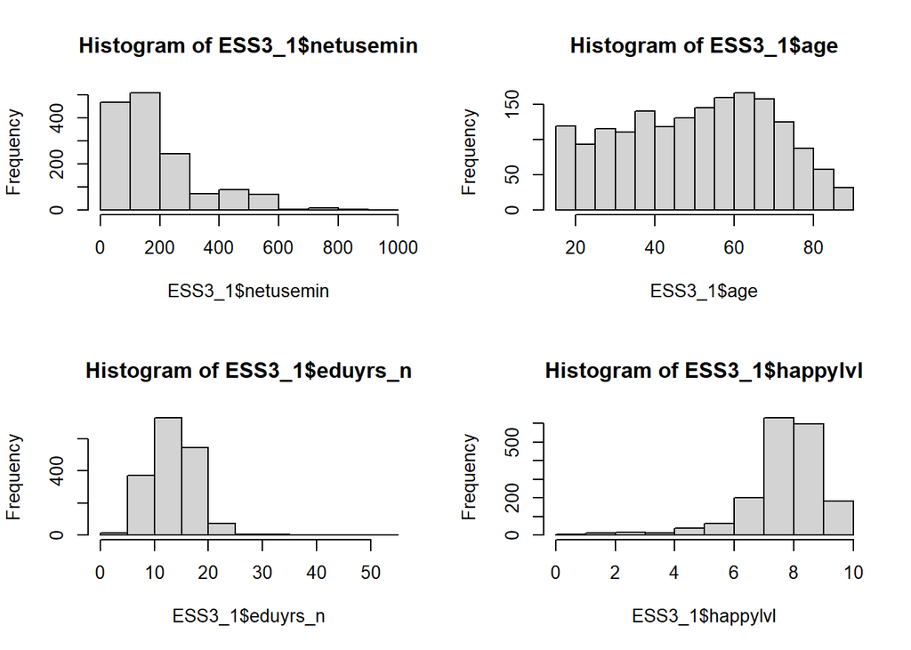

```r
par(mfrow=c(2,2))
hist(ESS3_1$netusemin)
hist(ESS3_1$age)
hist(ESS3_1$eduyrs_n)
hist(ESS3_1$happylvl)
```

As we can see, *Internet use, education years and happiness level* are visibly *not normal*, which is confirmed by their skewness. In case of *age*, it is different from the rest of the distributions, but still seems *not normal* due to its non-bell shape. However, since for Pearson’s correlation test we need to satisfy univariate normality in both variables in the relationship, and Internet use variable, to which we are going to compare age, is not normal already, we can dismiss this issue.

### Normality conclusion

3 out of 4 variables are not normal. The one that is can seemingly be close to being normally distributed is in pair with a not normal variable, which does not satisfy the univariate normality requirement.

## All assumptions conclusion

Our variables did not pass any of requirements for the Pearson’s correlation test, so we decided to use Spearman’s test instead.

## Correlation tests

Before running the Spearman’s correlation test, let’s spell out statistical hypotheses.

**H0**: there is no monotonic relationship between the two variables in the population (rho is equal to 0)

**H1**: there is a monotonic relationship between the two variables in the population (rho is not equal to 0)

```r
cor.test(ESS3_1$age, ESS3_1$netusemin, method = "spearman")
```

```
##
##  Spearman's rank correlation rho
##
## data:  ESS3_1$age and ESS3_1$netusemin
## S = 760994237, p-value < 2.2e-16
## alternative hypothesis: true rho is not equal to 0
## sample estimates:
##        rho
## -0.4432935
```

First of all, the *p-value* is very small, so there is a connection between those variables. In addition, *rho* is not equal to zero. Thus, we should reject the null hypothesis for those variables.

```r
cor.test(ESS3_1$eduyrs_n, ESS3_1$netusemin, method = "spearman")
```

```
##
##  Spearman's rank correlation rho
##
## data:  ESS3_1$eduyrs_n and ESS3_1$netusemin
## S = 423852629, p-value = 1.591e-13
## alternative hypothesis: true rho is not equal to 0
## sample estimates:
##       rho
## 0.1911771
```

Again, small *p-value* - presence of connection. *Rho* is not equal to zero, so we should reject the null hypothesis for these variables too.

```r
cor.test(ESS3_1$happylvl, ESS3_1$netusemin, method = "spearman")
```

```
##
##  Spearman's rank correlation rho
##
## data:  ESS3_1$happylvl and ESS3_1$netusemin
## S = 555202419, p-value = 0.04235
## alternative hypothesis: true rho is not equal to 0
## sample estimates:
##         rho
## -0.05299094
```

*P-value* is small, *rho* is not equal to zero - we should reject the null hypothesis.

## Correlation matrix

To see the results of the correlation test more clearly, let’s build a correlation matrix.

```r
tab_corr(ESS3_1[, 1:4],corr.method = "spearman")
```

|  | Internet use on a typical day, in minutes | Age of respondent, calculated | Years of full-time education completed | Happiness level, scale 0-10 |
| --- | --- | --- | --- | --- |
| Internet use on a typical day, in minutes |  | -0.442*** | 0.191*** | -0.052* |
| Age of respondent, calculated | -0.442*** |  | -0.009 | 0.068** |
| Years of full-time education completed | 0.191*** | -0.009 |  | 0.038 |
| Happiness level, scale 0-10 | -0.052* | 0.068** | 0.038 |  |
| Computed correlation used spearman-method with listwise-deletion. |  |  |  |  |

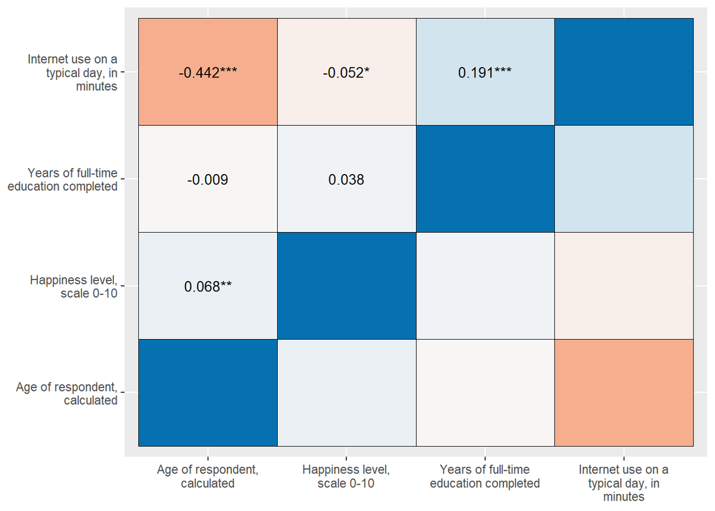

```r
sjp.corr(ESS3_1[, 1:4],corr.method = "spearman")
```

There are 3 correlation links that we are interested in:

- *Internet use - age*: statistically significant, negative, medium
- *Internet use - happiness level*: statistically significant, negative, very small
- *Internet use - number of years spent in education*: statistically significant, positive, small

The correlation matrix also displays statistically significant relationships between other variables, but we are focusing on Internet use links, so we ignore them.

## Boxplot for categorical predictor

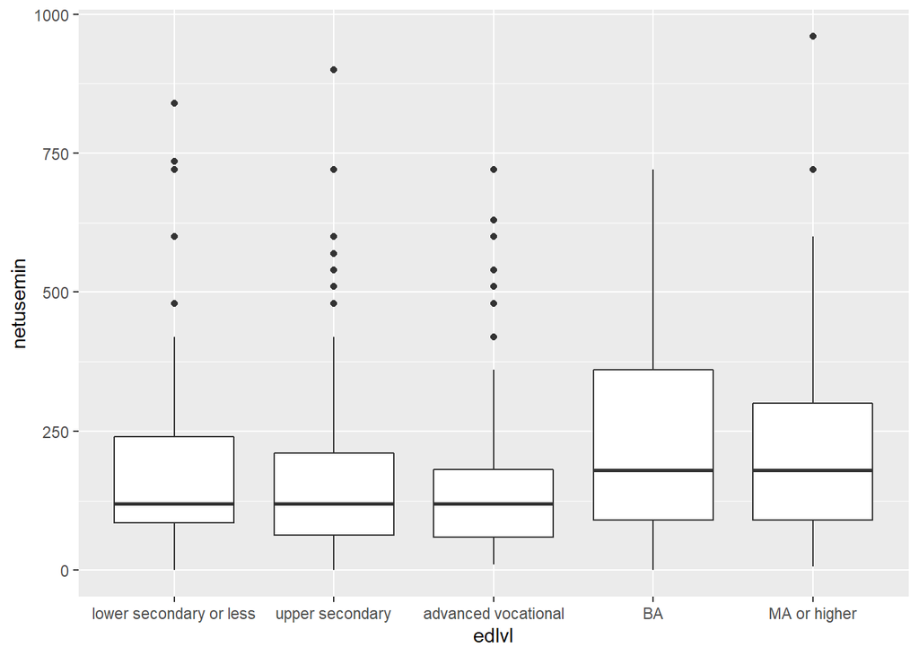

```r
ggplot(ESS3_2, aes(x=edlvl, y = netusemin)) +
  geom_boxplot()
```

People with higher education (BA and MA or higher) seem to have bigger variances in Internet use, i.e. the differences between 1st and 3rd quartiles in their case are bigger. Also, their 3rd and 4th quartiles are higher than in the rest of the groups, so we can suppose that respondents with higher education may show higher rates of Internet use, but still not statistically significant from others.

People with lower levels of education seem to have more noticable outliers.

# Regression

Now, we will build regression models adding predictors one by one and then compare the model fits.

```r
model1 <- lm(netusemin ~ age, data = ESS3_1)
summary(model1)
```

```
##
## Call:
## lm(formula = netusemin ~ age, data = ESS3_1)
##
## Residuals:
##     Min      1Q  Median      3Q     Max
## -248.55  -94.80  -41.11   56.58  768.30
##
## Coefficients:
##             Estimate Std. Error t value Pr(>|t|)
## (Intercept) 338.5171    10.8291   31.26   <2e-16 ***
## age          -3.1238     0.2164  -14.43   <2e-16 ***
## ---
## Signif. codes:  0 '***' 0.001 '**' 0.01 '*' 0.05 '.' 0.1 ' ' 1
##
## Residual standard error: 146 on 1466 degrees of freedom
##   (287 пропущенных наблюдений удалены)
## Multiple R-squared:  0.1244, Adjusted R-squared:  0.1238
## F-statistic: 208.3 on 1 and 1466 DF,  p-value: < 2.2e-16
```

```r
tab_model(model1, show.ci = F)
```

|  | Internet use on a typical day, in minutes |  |
| --- | --- | --- |
| Predictors | Estimates | p |
| (Intercept) | 338.52 | **<0.001** |
| Age of respondent, calculated | -3.12 | **<0.001** |
| Observations | 1468 |  |
| R<sup>2</sup> / R<sup>2</sup> adjusted | 0.124 / 0.124 |  |

```r
model2 <- lm(netusemin ~ age + eduyrs_n, data = ESS3_1)
summary(model2)
```

```
##
## Call:
## lm(formula = netusemin ~ age + eduyrs_n, data = ESS3_1)
##
## Residuals:
##     Min      1Q  Median      3Q     Max
## -356.16  -92.90  -36.92   52.66  710.87
##
## Coefficients:
##             Estimate Std. Error t value Pr(>|t|)
## (Intercept) 233.0840    17.1091  13.623  < 2e-16 ***
## age          -3.1322     0.2124 -14.746  < 2e-16 ***
## eduyrs_n      7.1518     0.9142   7.823 9.78e-15 ***
## ---
## Signif. codes:  0 '***' 0.001 '**' 0.01 '*' 0.05 '.' 0.1 ' ' 1
##
## Residual standard error: 143.2 on 1462 degrees of freedom
##   (290 пропущенных наблюдений удалены)
## Multiple R-squared:  0.1589, Adjusted R-squared:  0.1577
## F-statistic: 138.1 on 2 and 1462 DF,  p-value: < 2.2e-16
```

```r
tab_model(model2, show.ci = F)
```

|  | Internet use on a typical day, in minutes |  |
| --- | --- | --- |
| Predictors | Estimates | p |
| (Intercept) | 233.08 | **<0.001** |
| Age of respondent, calculated | -3.13 | **<0.001** |
| Years of full-time education completed | 7.15 | **<0.001** |
| Observations | 1465 |  |
| R<sup>2</sup> / R<sup>2</sup> adjusted | 0.159 / 0.158 |  |

```r
model3 <- lm(netusemin ~ age + eduyrs_n + happylvl, data = ESS3_1)
summary(model3)
```

```
##
## Call:
## lm(formula = netusemin ~ age + eduyrs_n + happylvl, data = ESS3_1)
##
## Residuals:
##     Min      1Q  Median      3Q     Max
## -355.51  -92.50  -38.28   52.80  713.43
##
## Coefficients:
##             Estimate Std. Error t value Pr(>|t|)
## (Intercept) 258.4582    28.3645   9.112  < 2e-16 ***
## age          -3.1111     0.2132 -14.590  < 2e-16 ***
## eduyrs_n      7.1967     0.9149   7.866 7.09e-15 ***
## happylvl     -3.2818     2.9262  -1.122    0.262
## ---
## Signif. codes:  0 '***' 0.001 '**' 0.01 '*' 0.05 '.' 0.1 ' ' 1
##
## Residual standard error: 143.2 on 1461 degrees of freedom
##   (290 пропущенных наблюдений удалены)
## Multiple R-squared:  0.1596, Adjusted R-squared:  0.1579
## F-statistic: 92.48 on 3 and 1461 DF,  p-value: < 2.2e-16
```

```r
tab_model(model3, show.ci = F)
```

|  | Internet use on a typical day, in minutes |  |
| --- | --- | --- |
| Predictors | Estimates | p |
| (Intercept) | 258.46 | **<0.001** |
| Age of respondent, calculated | -3.11 | **<0.001** |
| Years of full-time education completed | 7.20 | **<0.001** |
| Happiness level, scale 0-10 | -3.28 | 0.262 |
| Observations | 1465 |  |
| R<sup>2</sup> / R<sup>2</sup> adjusted | 0.160 / 0.158 |  |

```r
model4 <- lm(netusemin ~ age + eduyrs_n + happylvl + (as.character(edlvl)), data = ESS3_1)
summary(model4)
```

```
##
## Call:
## lm(formula = netusemin ~ age + eduyrs_n + happylvl + (as.character(edlvl)),
##     data = ESS3_1)
##
## Residuals:
##     Min      1Q  Median      3Q     Max
## -291.57  -93.16  -36.98   51.73  732.07
##
## Coefficients:
##                                            Estimate Std. Error t value Pr(>|t|)
## (Intercept)                                293.9046    35.9202   8.182 6.02e-16
## age                                         -3.1338     0.2217 -14.134  < 2e-16
## eduyrs_n                                     4.8565     1.3845   3.508 0.000465
## happylvl                                    -4.2174     2.9322  -1.438 0.150567
## as.character(edlvl)BA                       30.1325    13.2393   2.276 0.022992
## as.character(edlvl)lower secondary or less   7.3598    15.3699   0.479 0.632120
## as.character(edlvl)MA or higher             29.7029    14.2420   2.086 0.037189
## as.character(edlvl)upper secondary         -11.8557    11.6684  -1.016 0.309776
##
## (Intercept)                                ***
## age                                        ***
## eduyrs_n                                   ***
## happylvl
## as.character(edlvl)BA                      *
## as.character(edlvl)lower secondary or less
## as.character(edlvl)MA or higher            *
## as.character(edlvl)upper secondary
## ---
## Signif. codes:  0 '***' 0.001 '**' 0.01 '*' 0.05 '.' 0.1 ' ' 1
##
## Residual standard error: 142.7 on 1455 degrees of freedom
##   (292 пропущенных наблюдений удалены)
## Multiple R-squared:  0.1679, Adjusted R-squared:  0.1639
## F-statistic: 41.93 on 7 and 1455 DF,  p-value: < 2.2e-16
```

```r
tab_model(model4, show.ci = F)
```

|  | Internet use on a typical day, in minutes |  |
| --- | --- | --- |
| Predictors | Estimates | p |
| (Intercept) | 293.90 | **<0.001** |
| Age of respondent, calculated | -3.13 | **<0.001** |
| Years of full-time education completed | 4.86 | **<0.001** |
| Happiness level, scale 0-10 | -4.22 | 0.151 |
| as.character(edlvl)BA | 30.13 | **0.023** |
| as.character(edlvl)lower secondary or less | 7.36 | 0.632 |
| as.character(edlvl)MA or higher | 29.70 | **0.037** |
| as.character(edlvl)upper secondary | -11.86 | 0.310 |
| Observations | 1463 |  |
| R<sup>2</sup> / R<sup>2</sup> adjusted | 0.168 / 0.164 |  |

## Comparing model fits

To assess model fit we should look at R^2 and R^2 adjusted - they show “the relation of variance explained by the model to total variance of the outcome variable”. We can assume that R^2 >= 0.1 shows a satisfactory level of the predictive power our model holds. Also, the higher the R^2 (the closer to 1 or 100%) the better for us.

- **model 1**: R^2 / R^2 adjusted is 0.124 / 0.124 - it is higher than 0.1 and there is no difference - between two values of R^2
- **model 2**: R^2 / R^2 adjusted is 0.159 / 0.158 - it is higher than 0.1 and there is a small (0.001) difference between two values of R^2
- **model 3**: R^2 / R^2 adjusted is 0.160 / 0.158 - it is higher than 0.1 and there is a slightly higher difference (0.002 compared to 0 and 0.001 in model 1 and model 2 respectively) between two values of R^2
- **model 4**: R^2 / R^2 adjusted is 0.168 / 0.164 - it is higher than 0.1 and there is a higher difference (0.004 compared to 0, 0.001 and 0.002 in model 1, model 2 and model 3 respectively) between two values of R^2

## Interpreting the coefficients

Let’s see again the table for the chosen model.

```r
tab_model(model4, show.ci = F)
```

|  | Internet use on a typical day, in minutes |  |
| --- | --- | --- |
| Predictors | Estimates | p |
| (Intercept) | 293.90 | **<0.001** |
| Age of respondent, calculated | -3.13 | **<0.001** |
| Years of full-time education completed | 4.86 | **<0.001** |
| Happiness level, scale 0-10 | -4.22 | 0.151 |
| as.character(edlvl)BA | 30.13 | **0.023** |
| as.character(edlvl)lower secondary or less | 7.36 | 0.632 |
| as.character(edlvl)MA or higher | 29.70 | **0.037** |
| as.character(edlvl)upper secondary | -11.86 | 0.310 |
| Observations | 1463 |  |
| R<sup>2</sup> / R<sup>2</sup> adjusted | 0.168 / 0.164 |  |

# Regression equation

The regression equation consists of intercept estimate and each predictor’s estimates.

Our variables that will describe our regression equation:

- y - Internet use on a typical day, in minutes (outcome variable);
- a - Age of respondent, calculated;
- b - Years of full-time education completed;
- c - whether the person is at a BA level of education (dummy variable);
- d - whether the person is at a MA or higher level of education (dummy variable);
- intercept that is equal to 293.90.

The equation in our case will be the following:

**y = 293.90 - 3.13 * a + 4.86 * b + 30.13 * c + 29.70 * d**

# Output table

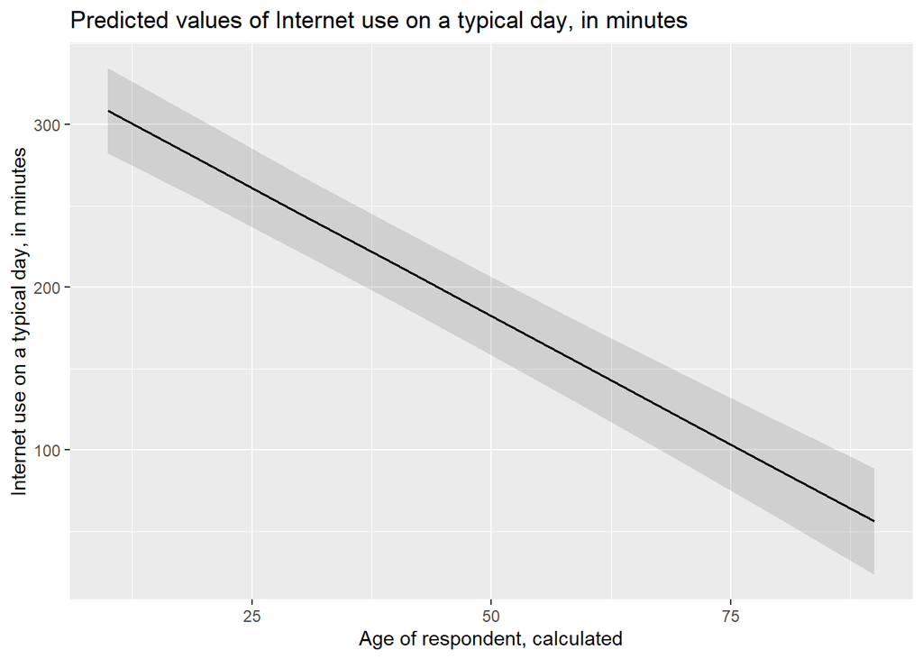

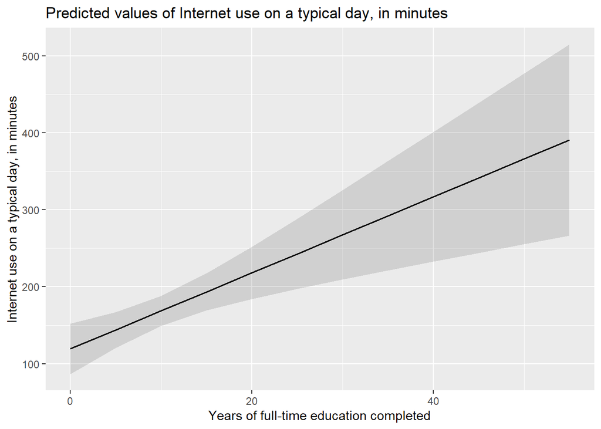

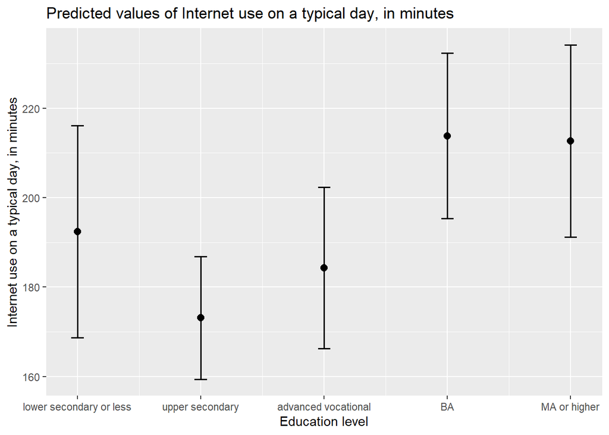

```r
netusemin_reg <- lm(netusemin ~ age + eduyrs_n + (as.character(edlvl)), data = ESS3_1)
sjPlot::plot_model(netusemin_reg, type = "pred")
```

## Output table

Now let’s construct the table with all significant predictors.

```r
sjPlot::tab_model(netusemin_reg)
```

|  | Internet use on a typical day, in minutes |  |  |
| --- | --- | --- | --- |
| Predictors | Estimates | CI | p |
| (Intercept) | 259.06 | 207.02 – 311.11 | **<0.001** |
| Age of respondent, calculated | -3.16 | -3.59 – -2.72 | **<0.001** |
| Years of full-time education completed | 4.93 | 2.22 – 7.65 | **<0.001** |
| as.character(edlvl)BA | 29.52 | 3.55 – 55.48 | **0.026** |
| as.character(edlvl)lower secondary or less | 8.12 | -22.02 – 38.27 | 0.597 |
| as.character(edlvl)MA or higher | 28.38 | 0.49 – 56.27 | **0.046** |
| as.character(edlvl)upper secondary | -11.19 | -34.07 – 11.69 | 0.337 |
| Observations | 1463 |  |  |
| R<sup>2</sup> / R<sup>2</sup> adjusted | 0.167 / 0.163 |  |  |

# Conclusion for the output table & overall project

The model only with significant predictors includes *Age of respondent, Years of education, Education level*.

- There is a negative connection between the Age of respondent and Internet use (-3.16), i.e. the Internet use slightly decreases (by ~ 3 minutes a day) as respondents get older
- this is coherent with our initial hypothesis.
- The connection between Years of education and Internet use is positive and also rather weak (4.93), i.e. the Internet use increases with each year respondent spent on education by approximately 5 minutes a day
- this is coherent with our initial hypothesis.
- The Education level predicts Internet use only in cases when the respondents have a higher education (BA, MA or higher); in those cases the connection is positive and rather strong, i.e. in both cases the internet use is higher by ~30 minutes a day than in the baseline case (advanced vocational)
- this is partly in line with our initial hypothesis as we expected people with higher education to use Internet more than with any other level of education and here we can see that this is true at least in comparison with one of the categories.

The Happiness level did not show statistically significant relationship with Internet use in case of regression model, so we can say that our initial hypothesis about this predictor was refuted. However, the correlation was significant but small.

# Bibliography

[1] Zickuhr, Kathryn, and Mary Madden. n.d. “Older Adults and Internet Use.” 23. https://www.sainetz.at/dokumente/studien/Older_adults_and_internet_use_2012.pdf

[2] Huxhold, O., E. Hees, and N. J. Webster. 2020. “Towards Bridging the Grey Digital Divide: Changes in Internet Access and Its Predictors from 2002 to 2014 in Germany.” European Journal of Ageing 17(3):271–80. doi: 10.1007/s10433-020-00552-z.

[3] Armstrong, Lynette, James G. Phillips, and Lauren L. Saling. 2000. “Potential Determinants of Heavier Internet Usage.” International Journal of Human-Computer Studies 53(4):537–50. [doi: 10.1006/ijhc.2000.0400.](https://www.sciencedirect.com/science/article/abs/pii/S1071581900904002)